# R Objects / Data Structure

R has many different structures for storing the data you want to analyze. The most commonly used are

- vectors,
- lists,
- matrices,
- arrays, and
- data frames.

It can be determined with the function `class()`.

The *type* or *mode* of an object defines how it is stored. It could be

- a character,
- a numeric value,
- an integer,
- a complex number, or
- a logical value (Boolean value: TRUE/FALSE).

It can be determined with the function `mode()`.

Below is a short definition and quick example of each of these data structures which you can use to decide which is the best for representing your data in R.

## Vectors

It is the most basic data type. Vectors only have one dimension and all their elements must be the same mode. There are various ways to create vectors. The simplest one is with the `c` function.

```r
(v1 <- c(1, 2, 5))
```

```
## [1] 1 2 5
```

The `c` function allows to combine its arguments. If the arguments are of various modes, they will be reduced to their lowest common type:

```r
(v2 <- c(1, 3, "a"))
```

```
## [1] "1" "3" "a"
```

```r
mode(v2)
```

```
## [1] "character"
```

Objects can be explicitly coerced with the `as.` function.

```r
as.character(v1)
```

```
## [1] "1" "2" "5"
```

You can also use the `:` operator or the `seq` function:

```r
1:10
```

```
##  [1]  1  2  3  4  5  6  7  8  9 10
```

```r
seq(from = 5, to = 25, by = 5)
```

```
## [1]  5 10 15 20 25
```

### Factors

Factor is a special type of vector to store categorical values.

```r
(breed <- factor(c("Holstein", "Holstein", "Brown Swiss", "Holstein",
                  "Ayrshire", "Canadian", "Canadian", "Brown Swiss",
                  "Holstein", "Brown Swiss", "Holstein")))
```

```
##  [1] Holstein    Holstein    Brown Swiss Holstein    Ayrshire
##  [6] Canadian    Canadian    Brown Swiss Holstein    Brown Swiss
## [11] Holstein
## Levels: Ayrshire Brown Swiss Canadian Holstein
```

It stores values as a set of labeled integers. Some functions treat factors differently from numeric vectors.

```r
table(breed)
```

```
## breed
##    Ayrshire Brown Swiss    Canadian    Holstein
##           1           3           2           5
```

## Lists

A list is an ordered collection of objects where the objects can be of different modes.

```r
(l <- list("a", "b", "c"))
```

```
## [[1]]
## [1] "a"
##
## [[2]]
## [1] "b"
##
## [[3]]
## [1] "c"
```

Each element of a list can be given a name and referred to by that name. Elements of a list can be accessed by their number or their name.

```r
(cow <- list(breed = "Holstein", age = 3, last.prod = c(25, 35, 32)))
```

```
## $breed
## [1] "Holstein"
##
## $age
## [1] 3
##
## $last.prod
## [1] 25 35 32
```

```r
cow$breed
```

```
## [1] "Holstein"
```

```r
cow[[1]]
```

```
## [1] "Holstein"
```

Lists can be used to hold together multiple values returned from a function. For example the elements used to create an histogram can be saved and returned:

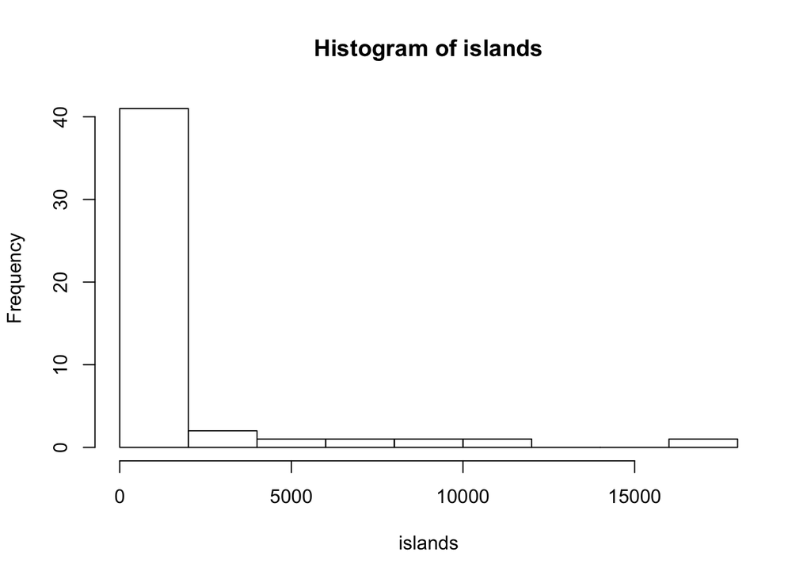

```r
h <- hist(islands)
```

```r
str(h)
```

```
## List of 6
##  $ breaks  : num [1:10] 0 2000 4000 6000 8000 10000 12000 14000 16000 18000
##  $ counts  : int [1:9] 41 2 1 1 1 1 0 0 1
##  $ density : num [1:9] 4.27e-04 2.08e-05 1.04e-05 1.04e-05 1.04e-05 ...
##  $ mids    : num [1:9] 1000 3000 5000 7000 9000 11000 13000 15000 17000
##  $ xname   : chr "islands"
##  $ equidist: logi TRUE
##  - attr(*, "class")= chr "histogram"
```

The function `str` is used here. It stands for *structure* and shows the internal structure of an R object.

## Matrices

A matrix is a rectangular array of numbers. Technically, it is a vector with two additional attributes: number of rows and number of columns. This is what you would use to analyze a spreadsheet full of only numbers, or only words. You can create a matrix with the `matrix` function:

```r
(m <- rbind(c(1, 4), c(2, 2)))
```

```
##      [,1] [,2]
## [1,]    1    4
## [2,]    2    2
```

```r
(m <- matrix(data = 1:12, nrow = 4, ncol = 3,
            dimnames = list(c("cow1", "cow2", "cow3", "cow4"),
                c("milk", "fat", "prot"))))
```

```
##      milk fat prot
## cow1    1   5    9
## cow2    2   6   10
## cow3    3   7   11
## cow4    4   8   12
```

## Arrays

If a matrix is a two-dimensional data structure, we can add *layers* to the data and have further dimensions in addition to rows and columns. These datasets would be arrays. It can be created with the `array` function:

```r
(a <- array(data = 1:24, dim = c(3, 4, 2)))
```

```
## , , 1
##
##      [,1] [,2] [,3] [,4]
## [1,]    1    4    7   10
## [2,]    2    5    8   11
## [3,]    3    6    9   12
##
## , , 2
##
##      [,1] [,2] [,3] [,4]
## [1,]   13   16   19   22
## [2,]   14   17   20   23
## [3,]   15   18   21   24
```

## Data frames

Data frames are used to store tabular data: multiple rows, columns and format.

```r
(df <- data.frame(cow = c("Moo-Moo", "Daisy", "Elsie"),
                 prod = c(35, 40, 28),
                 pregnant = c(TRUE, FALSE, TRUE)))
```

```
##       cow prod pregnant
## 1 Moo-Moo   35     TRUE
## 2   Daisy   40    FALSE
## 3   Elsie   28     TRUE
```